# Lab 6 - things that can go wrong

Ilaria Prosdocimi

# Body fat

Prendiamo in esame il dataset `bodyfat` che abbiamo già usato in un esercizio. Leggiamo i dati e trasformiamo altezza e e peso dalle misure imperiali (libbre e pollici) a misure decimali (Kg e cm).

```r
# urlLocation <- "https://dasl.datadescription.com/download/data/3079"
# bodyfat <- read.table(urlLocation, header=TRUE)
bodyfat <- read.csv("bodyfat.csv",header = TRUE)
bodyfat$Height <- bodyfat$Height * 2.54
bodyfat$Weight <- bodyfat$Weight / 2.205
#plot(bodyfat)
```

Una descrizione completa del dataset è disponibile [qui](http://jse.amstat.org/datasets/fat.txt); le variabili contenute nel dataset sono:

- Density: Percent body fat using Brozek’s equation, 457/Density - 414.2
- Pct.BF: Percent body fat using Siri’s equation, 495/Density - 450
- Age: Age (yrs)
- Weight: Weight (lbs)
- Height: Height (inches)
- Neck: Neck circumference (cm)
- Chest Chest circumference (cm)
- Abdomen/Waist: Abdomen circumference (cm) “at the umbilicus and level with the iliac crest”
- Hip: Hip circumference (cm)
- Thigh: Thigh circumference (cm)
- Knee: Knee circumference (cm)
- Ankle: Ankle circumference (cm)
- Bicep: Extended biceps circumference (cm)
- Forearm: Forearm circumference (cm)
- Wrist: Wrist circumference (cm) “distal to the styloid processes”

Si desidera costruire un modello per predire la percentuale di materia grassa di un individuo a partire dalle altre variabili. Possiamo iniziare con un modello che contenga tutti le variabili contenute nel dataset come predittori (tranne `Density`):

```r
## remove density
fit_all <- lm(Pct.BF~., data = bodyfat[,c(2:16)])
summary(fit_all)
```

```
##
## Call:
## lm(formula = Pct.BF ~ ., data = bodyfat[, c(2:16)])
##
## Residuals:
##      Min       1Q   Median       3Q      Max
## -10.9900  -3.1244  -0.1674   3.0248   9.8648
##
## Coefficients: (1 not defined because of singularities)
##             Estimate Std. Error t value Pr(>|t|)
## (Intercept)  1.68516   23.37412   0.072 0.942587
## Age          0.07189    0.03217   2.234 0.026389 *
## Weight      -0.03886    0.14804  -0.263 0.793153
## Height      -0.09715    0.07525  -1.291 0.197989
## Neck        -0.38682    0.23486  -1.647 0.100887
## Chest       -0.11919    0.10825  -1.101 0.272004
## Abdomen      0.90452    0.09140   9.897  < 2e-16 ***
## Waist             NA         NA      NA       NA
## Hip         -0.15878    0.14586  -1.089 0.277446
## Thigh        0.17299    0.14683   1.178 0.239926
## Knee        -0.04580    0.24560  -0.186 0.852230
## Ankle        0.18502    0.21985   0.842 0.400862
## Bicep        0.17968    0.17039   1.054 0.292732
## Forearm      0.27605    0.20692   1.334 0.183454
## Wrist       -1.80162    0.53304  -3.380 0.000848 ***
## ---
## Signif. codes:  0 '***' 0.001 '**' 0.01 '*' 0.05 '.' 0.1 ' ' 1
##
## Residual standard error: 4.255 on 236 degrees of freedom
## Multiple R-squared:  0.7505, Adjusted R-squared:  0.7368
## F-statistic: 54.61 on 13 and 236 DF,  p-value: < 2.2e-16
```

```r
fit_all <- lm(Pct.BF~., data = bodyfat[,c(2:7,9:16)])
summary(fit_all)
```

```
##
## Call:
## lm(formula = Pct.BF ~ ., data = bodyfat[, c(2:7, 9:16)])
##
## Residuals:
##      Min       1Q   Median       3Q      Max
## -10.9900  -3.1244  -0.1674   3.0248   9.8648
##
## Coefficients:
##             Estimate Std. Error t value Pr(>|t|)
## (Intercept)  1.68516   23.37412   0.072 0.942587
## Age          0.07189    0.03217   2.234 0.026389 *
## Weight      -0.03886    0.14804  -0.263 0.793153
## Height      -0.09715    0.07525  -1.291 0.197989
## Neck        -0.38682    0.23486  -1.647 0.100887
## Chest       -0.11919    0.10825  -1.101 0.272004
## Waist        2.29748    0.23215   9.897  < 2e-16 ***
## Hip         -0.15878    0.14586  -1.089 0.277446
## Thigh        0.17299    0.14683   1.178 0.239926
## Knee        -0.04580    0.24560  -0.186 0.852230
## Ankle        0.18502    0.21985   0.842 0.400862
## Bicep        0.17968    0.17039   1.054 0.292733
## Forearm      0.27605    0.20692   1.334 0.183454
## Wrist       -1.80162    0.53304  -3.380 0.000848 ***
## ---
## Signif. codes:  0 '***' 0.001 '**' 0.01 '*' 0.05 '.' 0.1 ' ' 1
##
## Residual standard error: 4.255 on 236 degrees of freedom
## Multiple R-squared:  0.7505, Adjusted R-squared:  0.7368
## F-statistic: 54.61 on 13 and 236 DF,  p-value: < 2.2e-16
```

```r
summary(lm(Pct.BF~Neck, data = bodyfat[,c(2:7,9:16)]))
```

```
##
## Call:
## lm(formula = Pct.BF ~ Neck, data = bodyfat[, c(2:7, 9:16)])
##
## Residuals:
##      Min       1Q   Median       3Q      Max
## -15.2061  -5.0721  -0.0904   5.3251  22.7099
##
## Coefficients:
##             Estimate Std. Error t value Pr(>|t|)
## (Intercept) -48.0929     7.6269  -6.306 1.31e-09 ***
## Neck          1.7690     0.2006   8.817  < 2e-16 ***
## ---
## Signif. codes:  0 '***' 0.001 '**' 0.01 '*' 0.05 '.' 0.1 ' ' 1
##
## Residual standard error: 7.252 on 248 degrees of freedom
## Multiple R-squared:  0.2387, Adjusted R-squared:  0.2356
## F-statistic: 77.74 on 1 and 248 DF,  p-value: < 2.2e-16
```

C’è una forte correlazione tr i predittori

```r
signif(cor(bodyfat[,c(2:7,9:16)]),2)
```

```
##         Pct.BF    Age Weight Height Neck Chest Waist    Hip Thigh  Knee Ankle
## Pct.BF   1.000  0.300  0.620 -0.029 0.49  0.70  0.82  0.630  0.55 0.490  0.24
## Age      0.300  1.000 -0.016 -0.250 0.12  0.18  0.24 -0.058 -0.22 0.017 -0.11
## Weight   0.620 -0.016  1.000  0.510 0.81  0.89  0.87  0.930  0.85 0.840  0.58
## Height  -0.029 -0.250  0.510  1.000 0.32  0.22  0.19  0.400  0.35 0.510  0.39
## Neck     0.490  0.120  0.810  0.320 1.00  0.77  0.73  0.710  0.67 0.650  0.43
## Chest    0.700  0.180  0.890  0.220 0.77  1.00  0.91  0.820  0.71 0.700  0.45
## Waist    0.820  0.240  0.870  0.190 0.73  0.91  1.00  0.860  0.74 0.710  0.41
## Hip      0.630 -0.058  0.930  0.400 0.71  0.82  0.86  1.000  0.88 0.810  0.52
## Thigh    0.550 -0.220  0.850  0.350 0.67  0.71  0.74  0.880  1.00 0.780  0.50
## Knee     0.490  0.017  0.840  0.510 0.65  0.70  0.71  0.810  0.78 1.000  0.59
## Ankle    0.240 -0.110  0.580  0.390 0.43  0.45  0.41  0.520  0.50 0.590  1.00
## Bicep    0.480 -0.044  0.790  0.320 0.71  0.71  0.66  0.720  0.74 0.650  0.45
## Forearm  0.360 -0.085  0.680  0.320 0.66  0.60  0.53  0.600  0.60 0.580  0.43
## Wrist    0.340  0.220  0.730  0.400 0.73  0.64  0.60  0.630  0.54 0.660  0.54
##          Bicep Forearm Wrist
## Pct.BF   0.480   0.360  0.34
## Age     -0.044  -0.085  0.22
## Weight   0.790   0.680  0.73
## Height   0.320   0.320  0.40
## Neck     0.710   0.660  0.73
## Chest    0.710   0.600  0.64
## Waist    0.660   0.530  0.60
## Hip      0.720   0.600  0.63
## Thigh    0.740   0.600  0.54
## Knee     0.650   0.580  0.66
## Ankle    0.450   0.430  0.54
## Bicep    1.000   0.700  0.61
## Forearm  0.700   1.000  0.60
## Wrist    0.610   0.600  1.00
```

```r
summary(lm(Pct.BF~Weight, data = bodyfat[,c(2:7,9:16)]))
```

```
##
## Call:
## lm(formula = Pct.BF ~ Weight, data = bodyfat[, c(2:7, 9:16)])
##
## Residuals:
##     Min      1Q  Median      3Q     Max
## -18.412  -4.744  -0.023   4.950  20.720
##
## Coefficients:
##              Estimate Std. Error t value Pr(>|t|)
## (Intercept) -14.69314    2.76045  -5.323 2.29e-07 ***
## Weight        0.41757    0.03379  12.357  < 2e-16 ***
## ---
## Signif. codes:  0 '***' 0.001 '**' 0.01 '*' 0.05 '.' 0.1 ' ' 1
##
## Residual standard error: 6.538 on 248 degrees of freedom
## Multiple R-squared:  0.3811, Adjusted R-squared:  0.3786
## F-statistic: 152.7 on 1 and 248 DF,  p-value: < 2.2e-16
```

```r
summary(lm(Pct.BF~Hip, data = bodyfat[,c(2:7,9:16)]))
```

```
##
## Call:
## lm(formula = Pct.BF ~ Hip, data = bodyfat[, c(2:7, 9:16)])
##
## Residuals:
##      Min       1Q   Median       3Q      Max
## -17.7862  -4.2203  -0.1467   4.4553  17.7606
##
## Coefficients:
##             Estimate Std. Error t value Pr(>|t|)
## (Intercept) -62.1198     6.3207  -9.828   <2e-16 ***
## Hip           0.8144     0.0633  12.866   <2e-16 ***
## ---
## Signif. codes:  0 '***' 0.001 '**' 0.01 '*' 0.05 '.' 0.1 ' ' 1
##
## Residual standard error: 6.436 on 248 degrees of freedom
## Multiple R-squared:  0.4003, Adjusted R-squared:  0.3979
## F-statistic: 165.5 on 1 and 248 DF,  p-value: < 2.2e-16
```

```r
summary(lm(Pct.BF~Weight+Hip, data = bodyfat[,c(2:7,9:16)]))
```

```
##
## Call:
## lm(formula = Pct.BF ~ Weight + Hip, data = bodyfat[, c(2:7, 9:16)])
##
## Residuals:
##      Min       1Q   Median       3Q      Max
## -18.1981  -4.1935  -0.1629   4.5087  18.4368
##
## Coefficients:
##              Estimate Std. Error t value Pr(>|t|)
## (Intercept) -48.52400   10.85559  -4.470 1.19e-05 ***
## Weight        0.14149    0.09198   1.538  0.12525
## Hip           0.56325    0.17501   3.218  0.00146 **
## ---
## Signif. codes:  0 '***' 0.001 '**' 0.01 '*' 0.05 '.' 0.1 ' ' 1
##
## Residual standard error: 6.418 on 247 degrees of freedom
## Multiple R-squared:  0.406,  Adjusted R-squared:  0.4012
## F-statistic:  84.4 on 2 and 247 DF,  p-value: < 2.2e-16
```

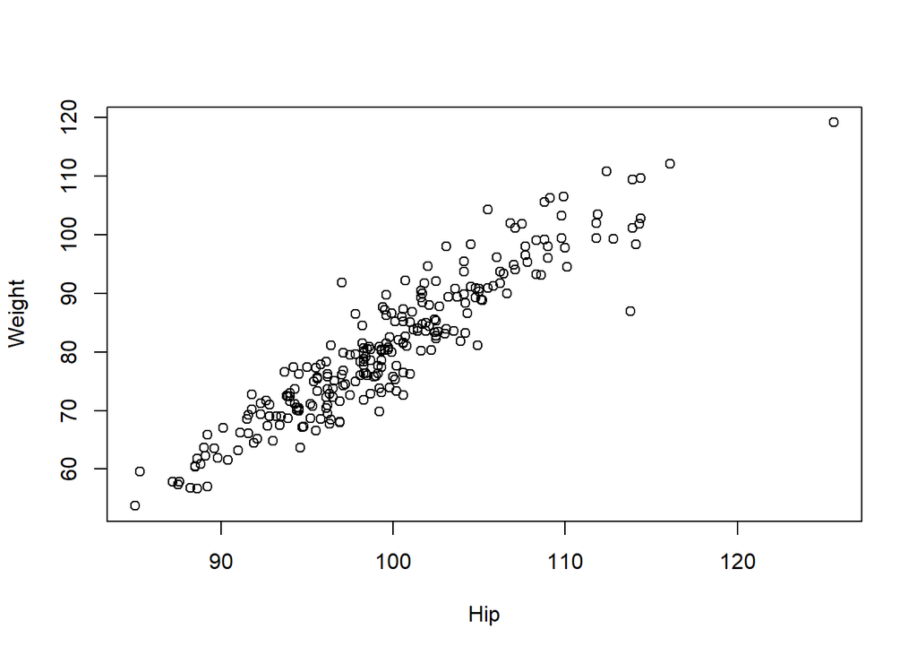

```r
plot(Weight~Hip, data = bodyfat)
```

```r
summary(lm(Weight~Hip, data = bodyfat))
```

```
##
## Call:
## lm(formula = Weight ~ Hip, data = bodyfat)
##
## Residuals:
##      Min       1Q   Median       3Q      Max
## -18.9122  -2.5246  -0.1512   2.2932  15.7785
##
## Coefficients:
##              Estimate Std. Error t value Pr(>|t|)
## (Intercept) -96.09063    4.35184  -22.08   <2e-16 ***
## Hip           1.77473    0.04358   40.72   <2e-16 ***
## ---
## Signif. codes:  0 '***' 0.001 '**' 0.01 '*' 0.05 '.' 0.1 ' ' 1
##
## Residual standard error: 4.431 on 248 degrees of freedom
## Multiple R-squared:  0.8699, Adjusted R-squared:  0.8694
## F-statistic:  1658 on 1 and 248 DF,  p-value: < 2.2e-16
```

```r
predict(lm(Pct.BF~Weight, data = bodyfat[,c(2:7,9:16)]), newdata = data.frame(Weight = 90, Hip = 110), se.fit = TRUE)$se.fit
```

```
## [1] 0.5181005
```

```r
predict(lm(Pct.BF~Hip, data = bodyfat[,c(2:7,9:16)]), newdata = data.frame(Weight = 90, Hip = 110), se.fit = TRUE)$se.fit
```

```
## [1] 0.7712153
```

```r
predict(lm(Pct.BF~Weight+Hip, data = bodyfat[,c(2:7,9:16)]), newdata = data.frame(Weight = 90, Hip = 110), se.fit = TRUE)$se.fit
```

```
## [1] 1.138698
```

```r
X <- model.matrix(fit_all)
eigen(crossprod(X))$values
```

```
##  [1] 1.778963e+07 4.272210e+04 3.163607e+04 3.663209e+03 2.356640e+03
##  [6] 1.258034e+03 6.212183e+02 5.234257e+02 4.417791e+02 3.349519e+02
## [11] 3.078329e+02 2.585606e+02 6.258052e+01 3.314237e-02
```

```r
car::vif(fit_all)
```

```
##       Age    Weight    Height      Neck     Chest     Waist       Hip     Thigh
##  2.278191 45.298843  3.439587  3.978898 10.712505 11.967579 12.146249  7.153711
##      Knee     Ankle     Bicep   Forearm     Wrist
##  4.441752  1.810253  3.409524  2.422878  3.263677
```

```r
fit_sub <- lm(Pct.BF ~ Ankle+Age+Forearm+Wrist+Bicep+Height+Neck+Knee+Thigh,
              data = bodyfat[, c(2:7, 9:16)])
summary(fit_sub)
```

```
##
## Call:
## lm(formula = Pct.BF ~ Ankle + Age + Forearm + Wrist + Bicep +
##     Height + Neck + Knee + Thigh, data = bodyfat[, c(2:7, 9:16)])
##
## Residuals:
##      Min       1Q   Median       3Q      Max
## -14.2323  -3.7530   0.0504   3.9870  19.1840
##
## Coefficients:
##              Estimate Std. Error t value Pr(>|t|)
## (Intercept) -18.07609   11.14795  -1.621  0.10623
## Ankle         0.17024    0.29197   0.583  0.56040
## Age           0.27116    0.03769   7.195 7.93e-12 ***
## Forearm       0.19084    0.27697   0.689  0.49147
## Wrist        -2.33826    0.70417  -3.321  0.00104 **
## Bicep         0.23291    0.22228   1.048  0.29578
## Height       -0.23149    0.07103  -3.259  0.00128 **
## Neck          0.47487    0.28696   1.655  0.09926 .
## Knee          0.53771    0.32021   1.679  0.09441 .
## Thigh         0.89855    0.15650   5.741 2.82e-08 ***
## ---
## Signif. codes:  0 '***' 0.001 '**' 0.01 '*' 0.05 '.' 0.1 ' ' 1
##
## Residual standard error: 5.762 on 240 degrees of freedom
## Multiple R-squared:  0.5348, Adjusted R-squared:  0.5174
## F-statistic: 30.66 on 9 and 240 DF,  p-value: < 2.2e-16
```

```r
car::vif(fit_sub)
```

```
##    Ankle      Age  Forearm    Wrist    Bicep   Height     Neck     Knee
## 1.741631 1.705156 2.367808 3.106669 3.165041 1.671671 3.239986 4.118350
##    Thigh
## 4.432824
```

```r
anova(fit_sub, fit_all)
```

```
## Analysis of Variance Table
##
## Model 1: Pct.BF ~ Ankle + Age + Forearm + Wrist + Bicep + Height + Neck +
##     Knee + Thigh
## Model 2: Pct.BF ~ Age + Weight + Height + Neck + Chest + Waist + Hip +
##     Thigh + Knee + Ankle + Bicep + Forearm + Wrist
##   Res.Df    RSS Df Sum of Sq      F    Pr(>F)
## 1    240 7967.9
## 2    236 4273.7  4    3694.1 50.998 < 2.2e-16 ***
## ---
## Signif. codes:  0 '***' 0.001 '**' 0.01 '*' 0.05 '.' 0.1 ' ' 1
```

```r
fit_sub2 <- lm(Pct.BF ~ Age+Forearm,
              data = bodyfat[, c(2:7, 9:16)])
summary(fit_sub2)
```

```
##
## Call:
## lm(formula = Pct.BF ~ Age + Forearm, data = bodyfat[, c(2:7,
##     9:16)])
##
## Residuals:
##      Min       1Q   Median       3Q      Max
## -14.5633  -5.6459  -0.1085   4.7517  26.4490
##
## Coefficients:
##              Estimate Std. Error t value Pr(>|t|)
## (Intercept) -36.64694    6.87498  -5.330 2.21e-07 ***
## Age           0.21533    0.03649   5.901 1.19e-08 ***
## Forearm       1.60537    0.22759   7.054 1.74e-11 ***
## ---
## Signif. codes:  0 '***' 0.001 '**' 0.01 '*' 0.05 '.' 0.1 ' ' 1
##
## Residual standard error: 7.259 on 247 degrees of freedom
## Multiple R-squared:  0.2401, Adjusted R-squared:  0.234
## F-statistic: 39.03 on 2 and 247 DF,  p-value: 1.869e-15
```

```r
car::vif(fit_sub2)
```

```
##      Age  Forearm
## 1.007298 1.007298
```

```r
anova(fit_sub2, fit_sub)
```

```
## Analysis of Variance Table
##
## Model 1: Pct.BF ~ Age + Forearm
## Model 2: Pct.BF ~ Ankle + Age + Forearm + Wrist + Bicep + Height + Neck +
##     Knee + Thigh
##   Res.Df     RSS Df Sum of Sq      F    Pr(>F)
## 1    247 13015.8
## 2    240  7967.9  7    5047.9 21.721 < 2.2e-16 ***
## ---
## Signif. codes:  0 '***' 0.001 '**' 0.01 '*' 0.05 '.' 0.1 ' ' 1
```

Concentriamoci ora su alcune varaibili:

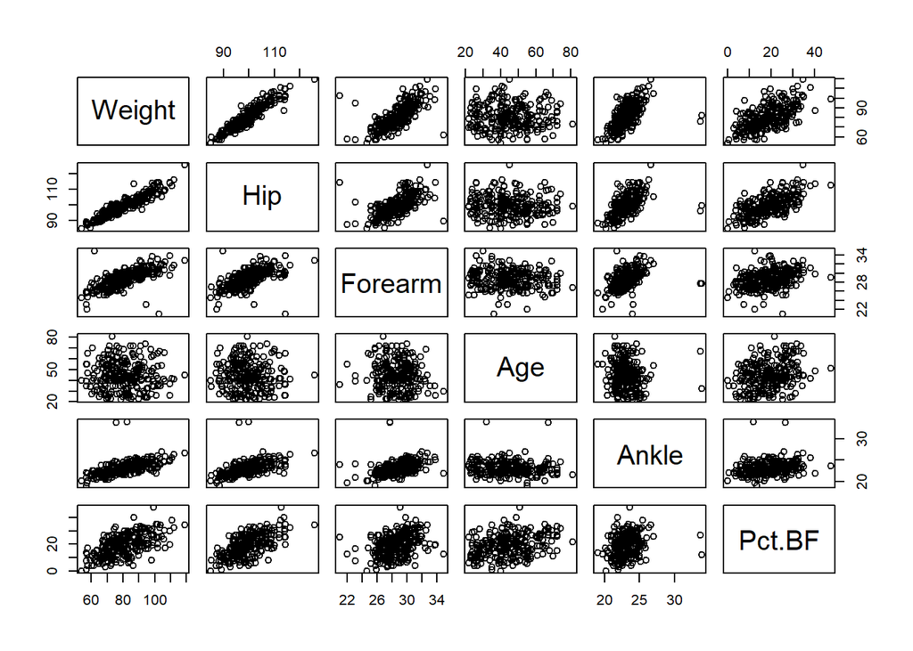

```r
plot(bodyfat[,c("Weight","Hip","Forearm","Age","Ankle","Pct.BF")])
```

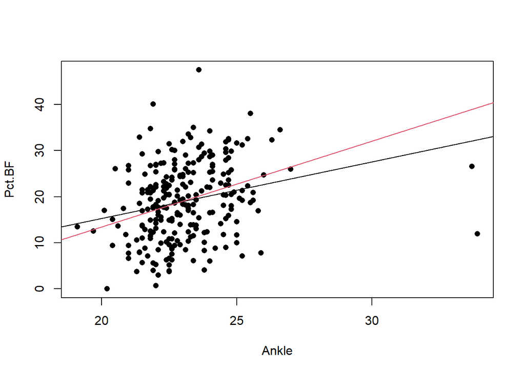

```r
plot(bodyfat[,c("Ankle","Pct.BF")], pch = 16)
abline(lm(Pct.BF  ~ Ankle, data  = bodyfat[,c("Ankle","Pct.BF")]), col = 1)
abline(lm(Pct.BF  ~ Ankle, data  = bodyfat[bodyfat$Ankle < 30,c("Ankle","Pct.BF")]), col = 2)
```

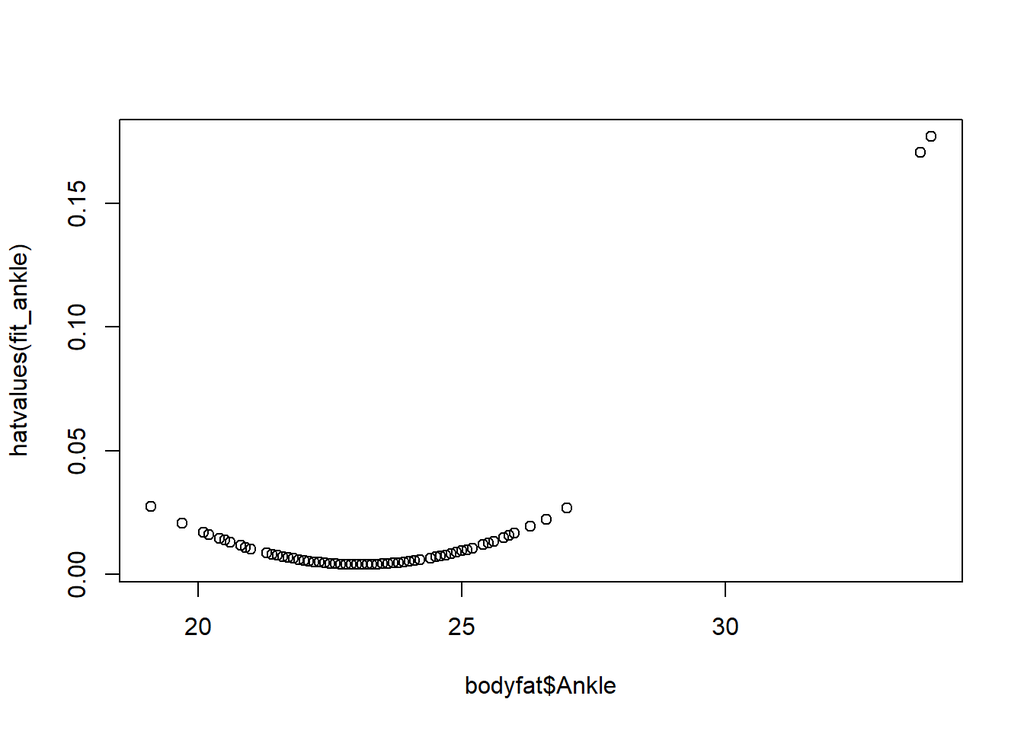

```r
fit_ankle <- lm(Pct.BF  ~ Ankle, data  = bodyfat[,c("Ankle","Pct.BF")])
plot(bodyfat$Ankle, hatvalues(fit_ankle))
```

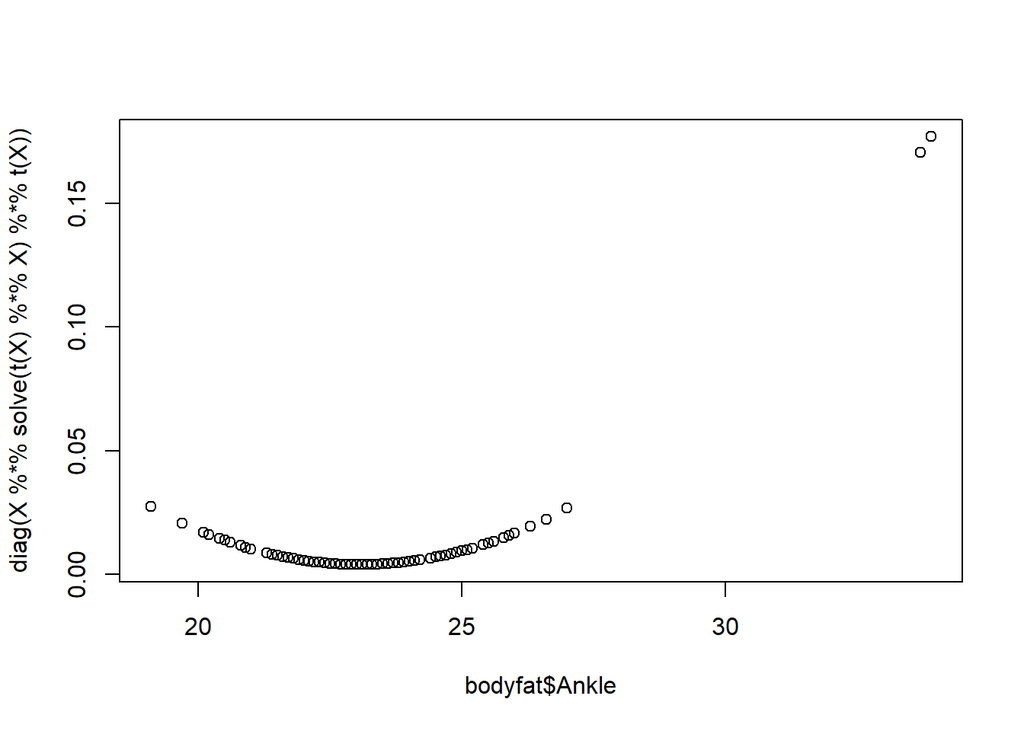

```r
X <- model.matrix(fit_ankle)
plot(bodyfat$Ankle, diag(X %*% solve(t(X) %*% X) %*% t(X)))
```

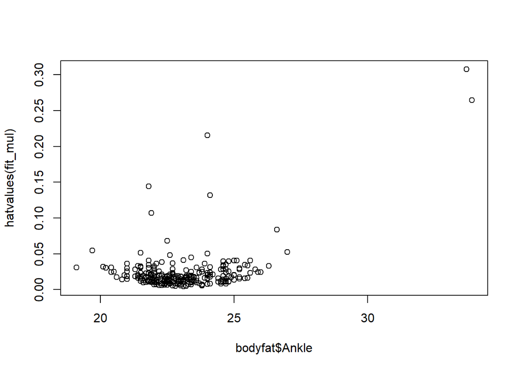

```r
fit_mul <- lm(Pct.BF~ ., bodyfat[,c("Weight","Hip","Forearm","Age","Ankle","Pct.BF")])
plot(bodyfat$Ankle, hatvalues(fit_mul))
```

```r
head(rstandard(fit_mul))
```

```
##          1          2          3          4          5          6
##  0.3582792 -1.2258967  2.3093118 -1.0913167  2.1710700  0.0253659
```

```r
head(residuals(fit_mul)/(summary(fit_mul)$sigma*sqrt(1-hatvalues(fit_mul))))
```

```
##          1          2          3          4          5          6
##  0.3582792 -1.2258967  2.3093118 -1.0913167  2.1710700  0.0253659
```

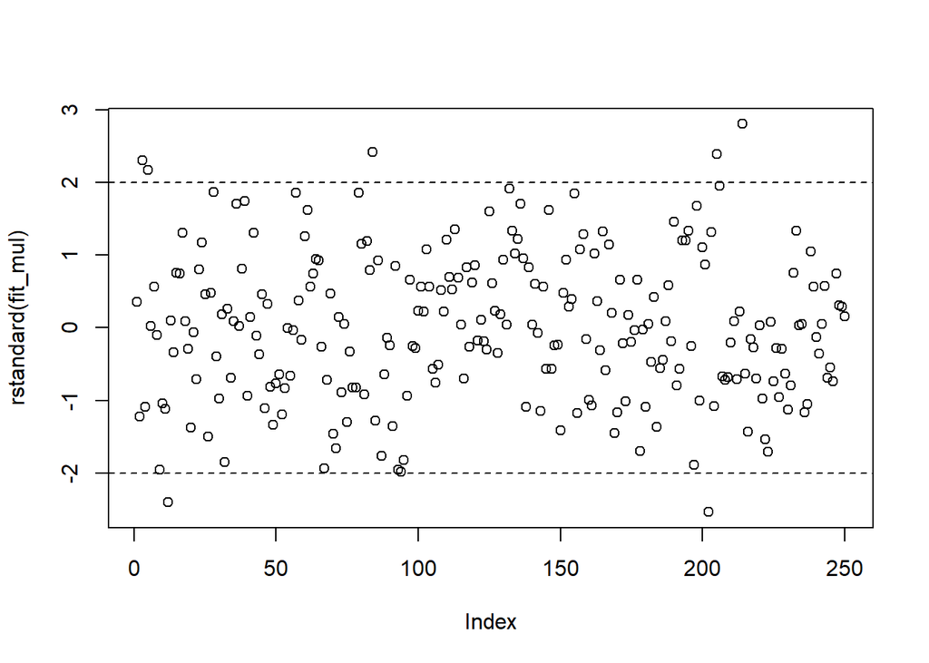

```r
plot(rstandard(fit_mul)); abline(h = c(-2,2), lty = 2)
```

```r
head(rstudent(fit_mul))
```

```
##          1          2          3          4          5          6
##  0.3576383 -1.2271671  2.3301799 -1.0917458  2.1878518  0.0253139
```

```r
i = 24
summary(fit_mul)$sigma
```

```
## [1] 5.803558
```

```r
summary(lm(Pct.BF ~ ., data = bodyfat[-i, c("Weight", "Hip", "Forearm", "Age", "Ankle", "Pct.BF")]))$sigma
```

```
## [1] 5.799166
```

```r
i = 84
predict(lm(Pct.BF ~ ., data = bodyfat[-i, c("Weight", "Hip", "Forearm", "Age", "Ankle", "Pct.BF")]), newdata = bodyfat[i, c("Weight", "Hip", "Forearm", "Age", "Ankle", "Pct.BF")])
```

```
##       84
## 9.746169
```

```r
bodyfat[i, c("Weight", "Hip", "Forearm", "Age", "Ankle", "Pct.BF")]
```

```
##      Weight  Hip Forearm Age Ankle Pct.BF
## 84 75.73696 96.2    27.7  67  33.7   26.6
```

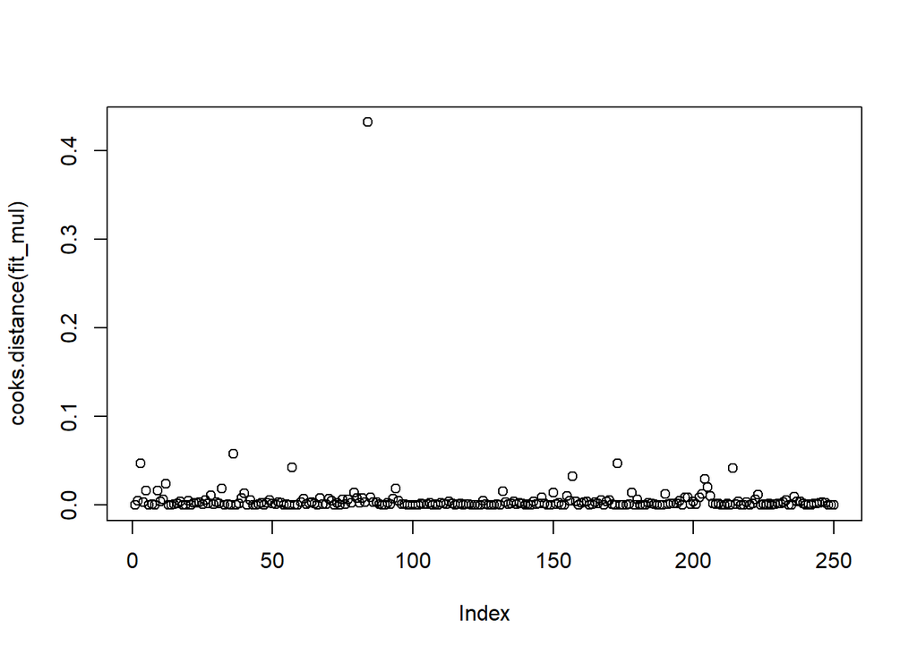

```r
plot(cooks.distance(fit_mul))
```

```r
fit_withoutlargeankles <- lm(lm(Pct.BF ~ ., data = bodyfat[, c("Weight", "Hip", "Forearm", "Age", "Ankle", "Pct.BF")], subset = bodyfat$Ankle <30))
summary(fit_withoutlargeankles)
```

```
##
## Call:
## lm(formula = lm(Pct.BF ~ ., data = bodyfat[, c("Weight", "Hip",
##     "Forearm", "Age", "Ankle", "Pct.BF")], subset = bodyfat$Ankle <
##     30))
##
## Residuals:
##      Min       1Q   Median       3Q      Max
## -14.0325  -3.8524  -0.4977   3.9588  15.6970
##
## Coefficients:
##              Estimate Std. Error t value Pr(>|t|)
## (Intercept) -40.72497   14.01159  -2.907  0.00399 **
## Weight        0.20814    0.09849   2.113  0.03559 *
## Hip           0.65054    0.15997   4.067 6.45e-05 ***
## Forearm      -0.04683    0.25115  -0.186  0.85222
## Age           0.18881    0.03013   6.265 1.69e-09 ***
## Ankle        -1.26234    0.40798  -3.094  0.00221 **
## ---
## Signif. codes:  0 '***' 0.001 '**' 0.01 '*' 0.05 '.' 0.1 ' ' 1
##
## Residual standard error: 5.741 on 242 degrees of freedom
## Multiple R-squared:  0.5314, Adjusted R-squared:  0.5218
## F-statistic:  54.9 on 5 and 242 DF,  p-value: < 2.2e-16
```

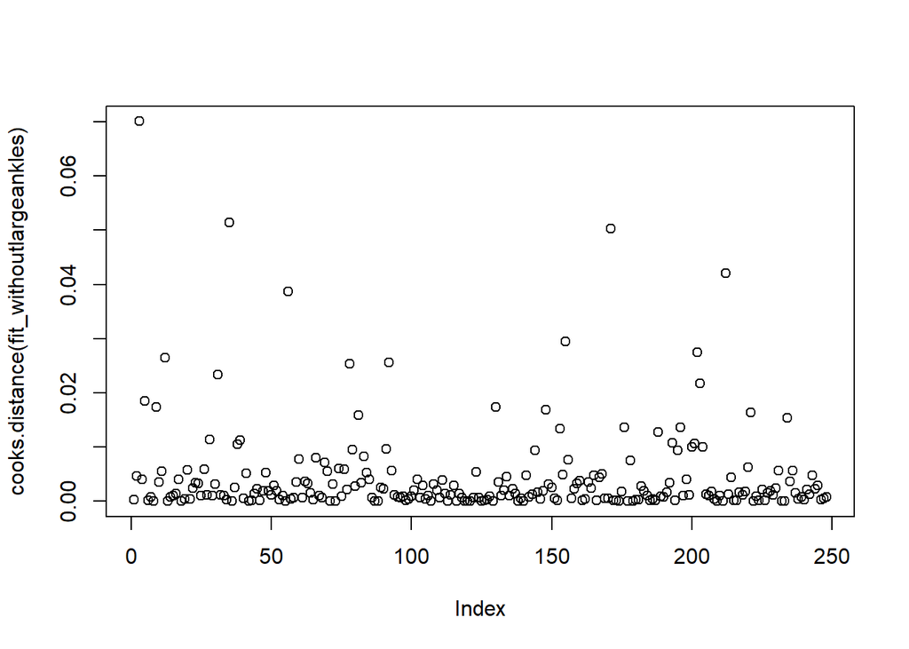

```r
plot(cooks.distance(fit_withoutlargeankles))
```

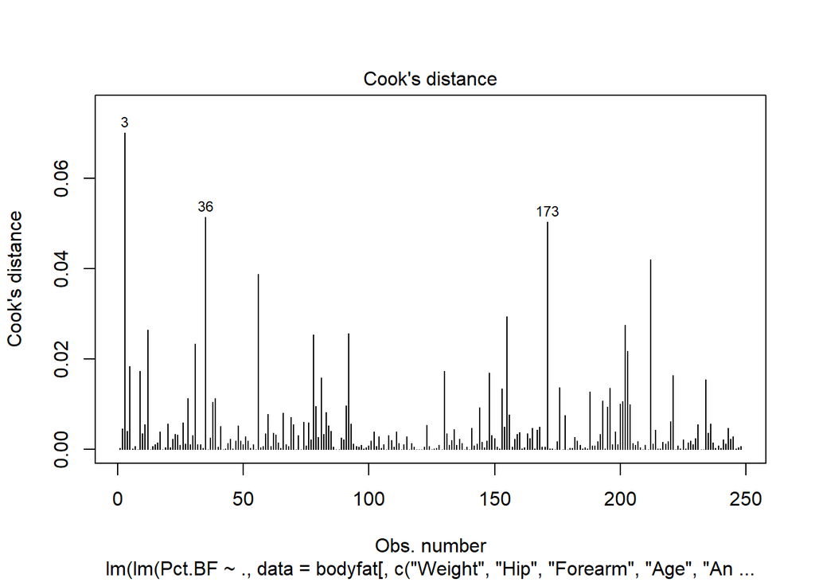

```r
plot(fit_withoutlargeankles, which = 4)
```

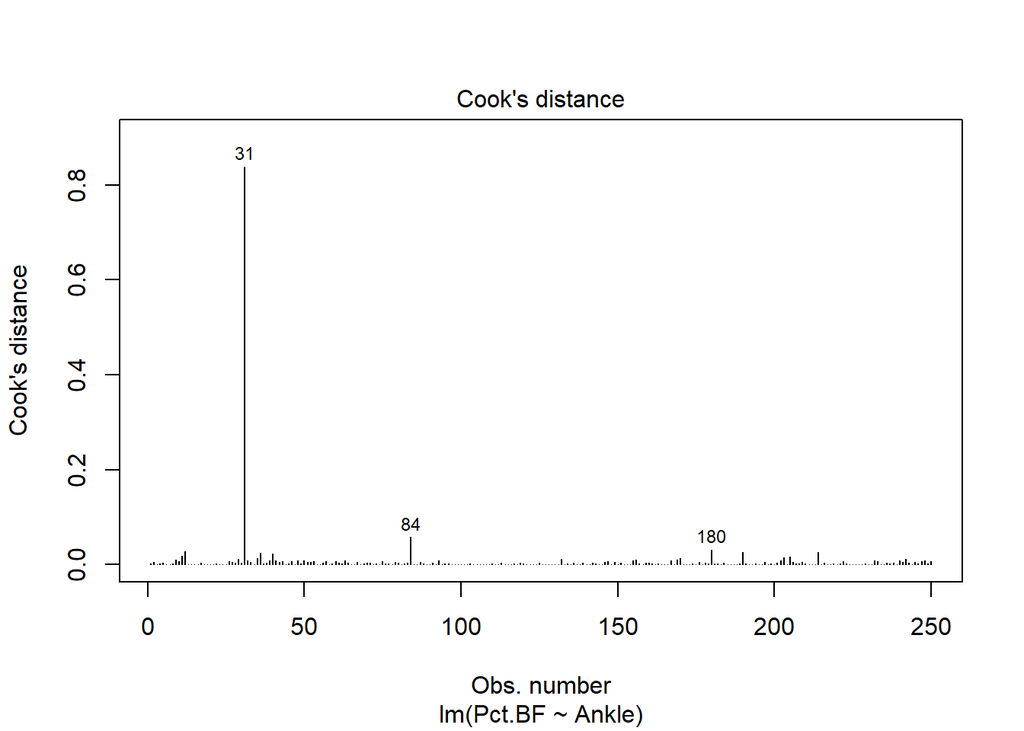

```r
plot(fit_ankle, which = 4)
```

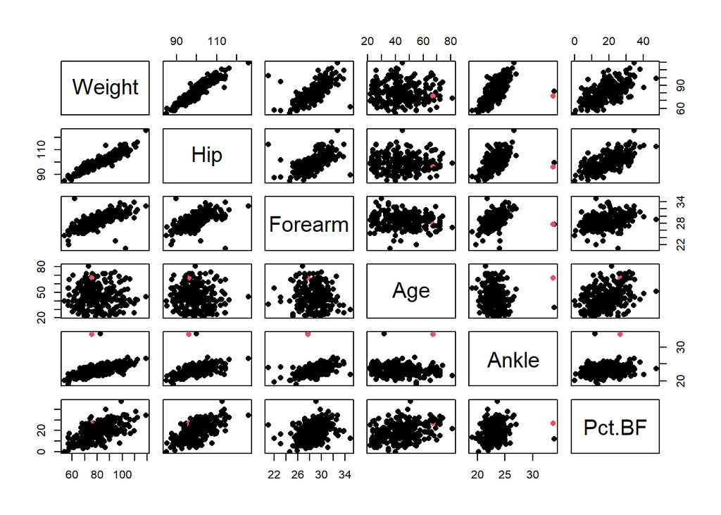

```r
 colvec <- rep(1,250); colvec[84] <- 2; plot(bodyfat[, c("Weight", "Hip", "Forearm", "Age", "Ankle", "Pct.BF")], col = colvec, pch = 16)
```

R permette di scegliere quali dei grafici far vedere

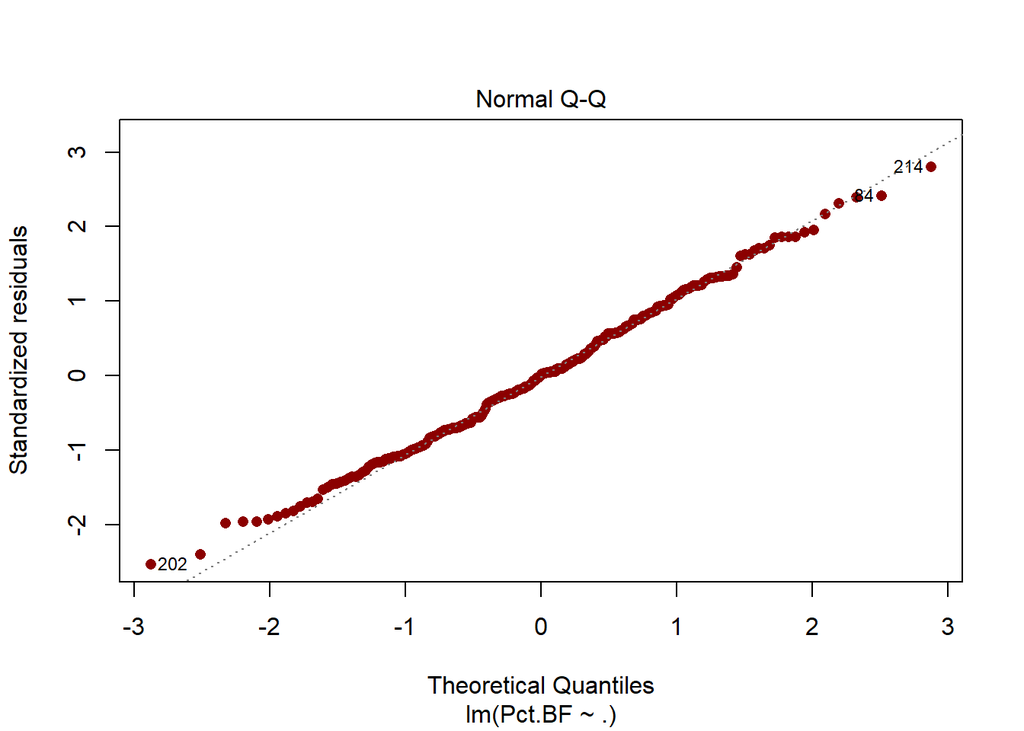

```r
par(mfrow=c(1,1)); plot(fit_mul, which=2, pch = 16, col = "darkred")
```